# Análisis Descriptivo. Mortalidad en personas Diabéticas Tipo 2 en comparación en Población Control

Jordi Real & Rai Puig

17 gener, 2020

## 0. Estado:

**Últimas actualizaciones**

✓ Análisis Descriptivo.  
✓ Gráfica Lexis.  
✓ Modelo de Poisson Tasas de Mortalidad.

**Realizado**

✓ Análisis Descriptivo  
✓ Gráfica Lexis  
✓ Modelo de Poisson Tasas de Mortalidad.

**Pendiente**

- Revisión y depuración de errores
- Edición de tablas

## 1. Objectivos Principales

- Análisis de las tendencias en mortalidad a lo largo del tiempo de todas las causas entre el 01.01.2004 y la captura más reciente del SIDIAP (31.12.2018) en personas con reciente diabetes tipo 2 y en comparación con 1 población control sin diabetes.
- Análisis de las diferncias y las proporciones de las tasas en mortalidad a lo largo del tiempo de todas las causas entre el 01.01.2004 y la captura más reciente del SIDIAP (31.12.2018) en personas con reciente diabetes tipo 2 y en comparación con 1 población control sin diabetes.

## 2. Objectivos Secundarios

- Análisis de las tendencias en mortalidad cardiovascular a lo largo del tiempo entre el 01.01.2004 y la captura más reciente del SIDIAP (31.12.2018) en personas con reciente diabetes tipo 2 y en comparación con 1 población control sin diabetes.
- Análisis de las diferncias y las proporciones de las tasas en mortalidad cardiovascular a lo largo del tiempo entre el 01.01.2004 y la captura más reciente del SIDIAP (31.12.2018) en personas con reciente diabetes tipo 2 y en comparación con 1 población control sin diabetes.
- Comparar las tendencias de las tasas de mortalidad y de ratio entre los diferentes países.
- Análisis de las tendencias del tiempo en condiciones renales cardiometabòliques.

## 4. Período de observación:

- 1 de enero del 2004 a 31 de diciembre del 2018

## 5. Análisis Estadístico

- Se describe el perfil demográfico y clínico del Grupo Caso(Diabético) incluidos, empreando los estadísticos más adecuados en cada caso, en función del tipo de variable.
- Se describe el perfil demográfico y clínico del Grupo Control incluidos. empreando los estadísticos más adecuados en cada caso, en función del tipo de variable.
- Generamos una curva de supervivencia, con el método Kaplan-Meier para ara el Grupo Caso(Diabético) y Grupo Control.(figura1)
- Aplicamos un Diagrama de Lexis para el Grupo Caso(Diabético) y Grupo Control.(figura2)
- Modelo lineal generalizado para ajustar una regresión de Poisson de la Tasas de todo tipo de Mortalidad ,para el Grupo Caso(Diabético) y Grupo Control.(figura3)

## 6. Resultados

**Perfil demográfico y clínico del Grupo Caso(Diabético) y Grupo Control**

|  | Grupo No Diabético (No Expuestos) | Grupo Diabético (Expuestos) |
| --- | --- | --- |
|  | N=550 | N=251 |
| Grupo: |  |  |
| Grupo No Diabético (No Expuestos) | 550 (100%) | 0 (0.00%) |
| Grupo Diabético (Expuestos) | 0 (0.00%) | 251 (100%) |
| Fecha Nacimiento | 08-Jan-1954 [09-Jan-1945;11-Jan-1962] | 11-Jan-1951 [07-Jan-1940;01-Jan-1959] |
| Sexo: |  |  |
| Hombre | 296 (53.8%) | 130 (51.8%) |
| Mujer | 254 (46.2%) | 121 (48.2%) |
| Fecha Índice | 20-Mar-2009 [08-Feb-2006;19-Apr-2012] | 10-Oct-2008 [06-Jan-2006;14-Feb-2012] |
| Número de Controles | 3.00 (1.44) | 2.19 (1.33) |
| situación: |  |  |
| Activo | 433 (78.7%) | 200 (79.7%) |
| Difunto | 49 (8.91%) | 32 (12.7%) |
| Trsalado | 68 (12.4%) | 19 (7.57%) |
| cociente albúmina creatina | 7.17 (7.37) | 14.5 (18.2) |
| Filtrado Glomerula | 81.5 (10.7) | 84.4 (9.87) |
| Colesterol LDL(Sérum) | 139 (29.8) | 140 (34.0) |
| Colesterol TOTAL(Sérum) | 220 (35.7) | 221 (39.2) |
| GLICADA(hbA1c) | 5.87 (1.34) | 7.50 (2.12) |
| Índice de Masa Corporal | 27.3 (4.57) | 30.8 (5.91) |
| Tabaco: |  |  |
| No Fumador | 131 (47.6%) | 75 (53.2%) |
| Fumador | 104 (37.8%) | 32 (22.7%) |
| Exfumador | 40 (14.5%) | 34 (24.1%) |
| IMC.dies[Valor] | 159 (107) | 71.6 (101) |
| Prescripciones.Inhibidores de la alfa glucosidasa: |  |  |
| No | 9 (100%) | 106 (99.1%) |
| Si | 0 (0.00%) | 1 (0.93%) |
| Prescripciones.Otros fármacos no incluyendo insulinas: |  |  |
| No | 9 (100%) | 104 (97.2%) |

[output cut: 55 more lines]

```
## [1] "Curva de supervivencia, con el método Kaplan-Meier para ara el Grupo Caso(Diabético) y Grupo Control(figura1)"
```

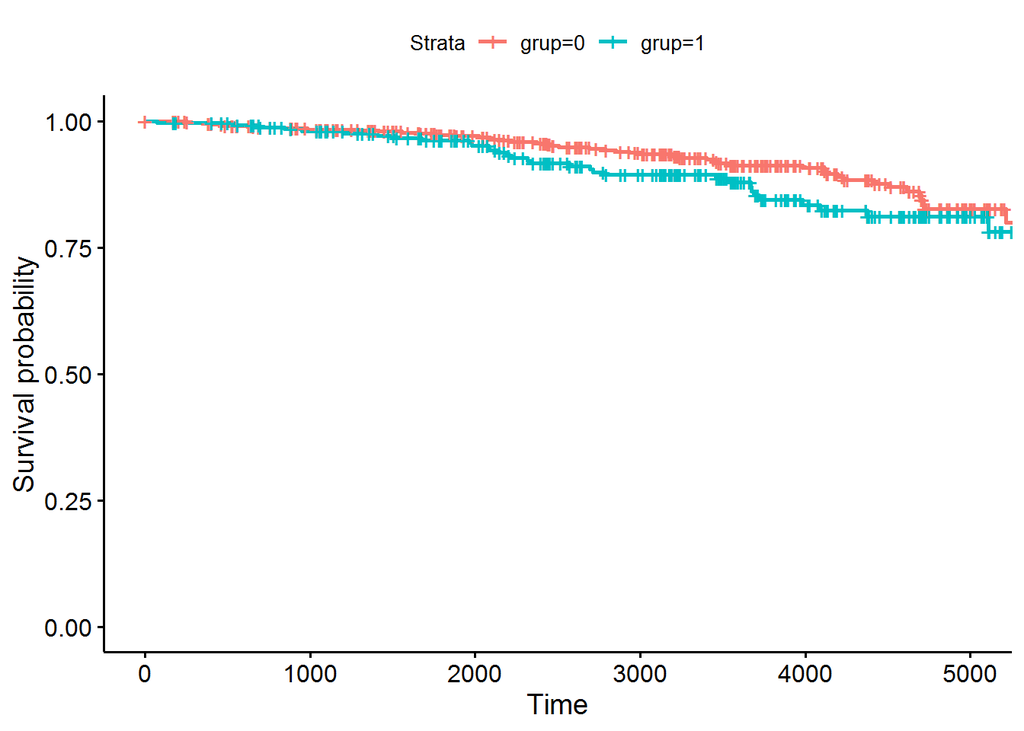

- Aplicamos un Diagrama de Lexis para el Grupo Caso(Diabético)(figura2a)

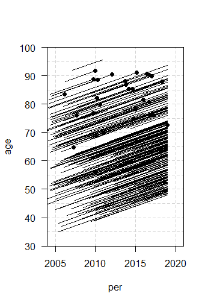

- Aplicamos un Diagrama de Lexis para el Grupo Control(figura2b).

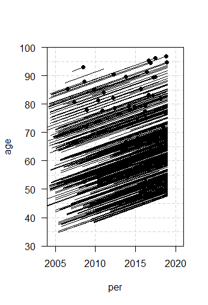

```
## [1] "Modelo lineal generalizado para ajustar un modelo de regresión de Poisson de la Tasas de  todo tipo de Mortalidad ,para el Grupo Caso(Diabético).(figura3)"
```

```
##
## Call:
## glm(formula = (lex.Xst == 1) ~ Ns(age, knots = a.kn) * Ns(per,
##     knots = p.kn) * gender, family = poisson(), data = dbs1,
##     offset = log(lex.dur))
##
## Deviance Residuals:
##     Min       1Q   Median       3Q      Max
## -1.1485  -0.0448   0.0000   0.0000   3.4011
##
## Coefficients:
##                                                        Estimate Std. Error
## (Intercept)                                          -3.120e+00  6.900e-01
## Ns(age, knots = a.kn)1                               -7.220e-01  2.324e+00
## Ns(age, knots = a.kn)2                                1.975e+00  1.199e+00
## Ns(age, knots = a.kn)3                                1.979e+00  9.645e-01
## Ns(age, knots = a.kn)4                                1.468e+00  1.076e+00
## Ns(per, knots = p.kn)1                               -2.921e+01  3.805e+01
## Ns(per, knots = p.kn)2                               -2.669e+02  2.122e+02
## Ns(per, knots = p.kn)3                               -2.343e+03  1.031e+03
## Ns(per, knots = p.kn)4                               -3.510e+03  1.529e+03
## gender                                               -3.048e+00  1.871e+00
## Ns(age, knots = a.kn)1:Ns(per, knots = p.kn)1        -8.739e+01  7.123e+01
## Ns(age, knots = a.kn)2:Ns(per, knots = p.kn)1         3.362e+01  3.218e+01
## Ns(age, knots = a.kn)3:Ns(per, knots = p.kn)1         5.669e+01  7.366e+01
## Ns(age, knots = a.kn)4:Ns(per, knots = p.kn)1         8.400e+00  2.920e+01
## Ns(age, knots = a.kn)1:Ns(per, knots = p.kn)2         3.804e+02  2.278e+02
## Ns(age, knots = a.kn)2:Ns(per, knots = p.kn)2         1.991e+02  1.645e+02
## Ns(age, knots = a.kn)3:Ns(per, knots = p.kn)2         4.809e+02  4.115e+02
## Ns(age, knots = a.kn)4:Ns(per, knots = p.kn)2         1.054e+02  6.363e+01
## Ns(age, knots = a.kn)1:Ns(per, knots = p.kn)3         1.337e+03  5.751e+02
## Ns(age, knots = a.kn)2:Ns(per, knots = p.kn)3         1.730e+03  7.579e+02
## Ns(age, knots = a.kn)3:Ns(per, knots = p.kn)3         4.930e+03  2.170e+03
## Ns(age, knots = a.kn)4:Ns(per, knots = p.kn)3         3.931e+02  1.704e+02
## Ns(age, knots = a.kn)1:Ns(per, knots = p.kn)4         1.876e+03  7.930e+02
## Ns(age, knots = a.kn)2:Ns(per, knots = p.kn)4         2.589e+03  1.121e+03
## Ns(age, knots = a.kn)3:Ns(per, knots = p.kn)4         7.425e+03  3.240e+03
## Ns(age, knots = a.kn)4:Ns(per, knots = p.kn)4         5.536e+02  2.370e+02
## Ns(age, knots = a.kn)1:gender                         1.994e+01  9.413e+00
## Ns(age, knots = a.kn)2:gender                        -3.962e+02  2.476e+02
```

[output cut: 68 more lines]

```
## Ns(age, knots = a.kn)4:Ns(per, knots = p.kn)3:gender   0.229   0.8185
## Ns(age, knots = a.kn)1:Ns(per, knots = p.kn)4:gender  -2.306   0.0211 *
## Ns(age, knots = a.kn)2:Ns(per, knots = p.kn)4:gender  -2.184   0.0289 *
## Ns(age, knots = a.kn)3:Ns(per, knots = p.kn)4:gender  -0.074   0.9413
## Ns(age, knots = a.kn)4:Ns(per, knots = p.kn)4:gender   0.256   0.7981
## ---
## Signif. codes:  0 '***' 0.001 '**' 0.01 '*' 0.05 '.' 0.1 ' ' 1
##
## (Dispersion parameter for poisson family taken to be 1)
##
##     Null deviance: 325.53  on 4113  degrees of freedom
## Residual deviance: 166.83  on 4064  degrees of freedom
## AIC: 324.83
##
## Number of Fisher Scoring iterations: 25
```

```
## [1] "Modelo lineal generalizado para ajustar un modelo de regresión de Poisson de la Tasas de  todo tipo de Mortalidad ,para e Grupo Control(figura4)"
```

```
##
## Call:
## glm(formula = (lex.Xst == 1) ~ Ns(age, knots = a.kn) * Ns(per,
##     knots = p.kn) * gender, family = poisson, data = dbs1, offset = log(lex.dur))
##
## Deviance Residuals:
##        Min          1Q      Median          3Q         Max
## -3.617e+44  -3.129e+44  -2.546e+44  -1.798e+44  -9.463e+42
##
## Coefficients:
##                                                        Estimate Std. Error
## (Intercept)                                           2.045e+02  1.133e-46
## Ns(age, knots = a.kn)1                                4.910e-15  3.912e-46
## Ns(age, knots = a.kn)2                                3.940e-15  5.055e-46
## Ns(age, knots = a.kn)3                               -1.731e-15  5.081e-46
## Ns(age, knots = a.kn)4                                6.667e-15  8.555e-46
## Ns(per, knots = p.kn)1                                1.194e-15  3.559e-46
## Ns(per, knots = p.kn)2                               -7.577e-16  2.843e-46
## Ns(per, knots = p.kn)3                                3.409e-15  2.474e-46
## Ns(per, knots = p.kn)4                               -7.409e-16  2.795e-46
## gender                                                2.230e-16  1.518e-46
## Ns(age, knots = a.kn)1:Ns(per, knots = p.kn)1        -2.671e-15  1.279e-45
## Ns(age, knots = a.kn)2:Ns(per, knots = p.kn)1        -5.064e-15  1.688e-45
## Ns(age, knots = a.kn)3:Ns(per, knots = p.kn)1        -5.963e-15  1.303e-45
## Ns(age, knots = a.kn)4:Ns(per, knots = p.kn)1        -1.114e-15  1.710e-45
## Ns(age, knots = a.kn)1:Ns(per, knots = p.kn)2        -4.272e-15  1.034e-45
## Ns(age, knots = a.kn)2:Ns(per, knots = p.kn)2        -1.029e-15  1.271e-45
## Ns(age, knots = a.kn)3:Ns(per, knots = p.kn)2         1.189e-14  1.059e-45
## Ns(age, knots = a.kn)4:Ns(per, knots = p.kn)2        -3.491e-15  1.127e-45
## Ns(age, knots = a.kn)1:Ns(per, knots = p.kn)3        -6.946e-15  8.026e-46
## Ns(age, knots = a.kn)2:Ns(per, knots = p.kn)3        -4.891e-16  9.462e-46
## Ns(age, knots = a.kn)3:Ns(per, knots = p.kn)3        -8.051e-15  1.211e-45
## Ns(age, knots = a.kn)4:Ns(per, knots = p.kn)3        -9.794e-15  1.847e-45
## Ns(age, knots = a.kn)1:Ns(per, knots = p.kn)4        -2.203e-15  1.006e-45
## Ns(age, knots = a.kn)2:Ns(per, knots = p.kn)4        -7.793e-15  1.170e-45
## Ns(age, knots = a.kn)3:Ns(per, knots = p.kn)4         3.251e-15  1.046e-45
## Ns(age, knots = a.kn)4:Ns(per, knots = p.kn)4        -9.326e-16  1.252e-45
## Ns(age, knots = a.kn)1:gender                        -9.462e-14  7.348e-46
## Ns(age, knots = a.kn)2:gender                        -4.753e-15  3.586e-45
## Ns(age, knots = a.kn)3:gender                         2.976e-13  2.009e-44
```

[output cut: 118 more lines]

```
## Ns(age, knots = a.kn)4:Ns(per, knots = p.kn)3:gender ***
## Ns(age, knots = a.kn)1:Ns(per, knots = p.kn)4:gender ***
## Ns(age, knots = a.kn)2:Ns(per, knots = p.kn)4:gender ***
## Ns(age, knots = a.kn)3:Ns(per, knots = p.kn)4:gender ***
## Ns(age, knots = a.kn)4:Ns(per, knots = p.kn)4:gender ***
## ---
## Signif. codes:  0 '***' 0.001 '**' 0.01 '*' 0.05 '.' 0.1 ' ' 1
##
## (Dispersion parameter for poisson family taken to be 1)
##
##     Null deviance: 5.2421e+02  on 8798  degrees of freedom
## Residual deviance: 5.6316e+92  on 8749  degrees of freedom
## AIC: 5.6316e+92
##
## Number of Fisher Scoring iterations: 25
```

[output not shown]